# Sharafi_HW8

## Question 2

**Tutorial steps for Strings from Chapter 14** **14.2.5 #3** There are two approaches to deal with even numbers since we do not have a middle letter on them. I wrote both of the possible ways.

```r
library(tidyverse)
x <- c("Apple", "Banana", "Pear")
str_sub(x,(str_length(x)+1)/2, (str_length(x)+1)/2) # Choose integr before middle
```

```
## [1] "p" "n" "e"
```

```r
str_sub(x,ceiling((str_length(x)+1)/2), ceiling((str_length(x)+1)/2))#choose integer after middle
```

```
## [1] "p" "a" "a"
```

**14.2.5 #4** Format a string by warping the text and modifying width and indentation.WHen we have a long text in string data.

**14.2.5 #5** Eliminate spaces at the beginning or end of a string. Remove the vacant spaces between text and quotation on both sides.

**14.2.5 #6** Function that turns a vector into the string

```r
string_maker <- function(x){n <- length(x)
y <- c()
# Create a particular condition when the length of the vector is 0,1,2
  if (n == 0) {
    NULL
  }else if  (n == 1){
  str_c(" ", x, " ")
}else if  (n == 2){
  str_c(" ",x[[1]], ",and", x[[2]]," ",sep =" " )}
else {
  for(i in 1:(n-1)){y <- str_c(y," ",x[[i]],",")}
  y <- str_c(y," and"," ",x[[n]])
  y
}
}
```

**14.3.1.1 #3**

“\..\..\..”, we know that “\.” will match with “.” and then another “.” can represent any character so it will be something like the following:

```r
str_view(c(".a.a.a","abc", "a.b"), "\\..\\..\\..")
```

[interactive chart not shown]

**14.3.3.1 #1** **1.**Start with a vowel.

```r
str_view(c("why","apple","enter","booked","nine","item"),("^[aeiou]"))
```

[interactive chart not shown]

**2.**That only contain consonants.

```r
str_view(c("why","apple","enter","booked","nine","item"), "^[^aeiou]+$")
```

[interactive chart not shown]

**3.**d with ed, but not with eed.

```r
str_view(c("why","apple","entering","booked","nine","item","seed"),"[^e]ed$")
```

[interactive chart not shown]

**4.**End with ing or ise

```r
str_view(c("why","apple","entering","booked","nine","item","seed","wise"),"[i](se|ng)$")
```

[interactive chart not shown]

**14.3.4.1 #2** **1.**^.*$This is going to match whatever It’s there **2.**`"\\{.+\\}"`At least one character inside of curly braces **3.**`\d{4}-\d{2}-\d{2}` It is lookate like the date format 2020-22-03 **4.**“\\{4}” ,it is expressing “\\\\” but mine is not working with ’’

**14.4.3.1 #2**

```r
#define the contractions
contract <- "([A-Za-z]+)'([A-Za-z]+)"
ans <-  str_extract(sentences, contract) %>% na.omit() %>% str_split("'",simplify = TRUE)
ans
```

```
##       [,1]       [,2]
##  [1,] "It"       "s"
##  [2,] "man"      "s"
##  [3,] "don"      "t"
##  [4,] "store"    "s"
##  [5,] "workmen"  "s"
##  [6,] "Let"      "s"
##  [7,] "sun"      "s"
##  [8,] "child"    "s"
##  [9,] "king"     "s"
## [10,] "It"       "s"
## [11,] "don"      "t"
## [12,] "queen"    "s"
## [13,] "don"      "t"
## [14,] "pirate"   "s"
## [15,] "neighbor" "s"
```

**14.4.4.1 #1** Replace all forward slashes in a string with backslashes.

```r
str_replace_all("c/desktop/es207/hw/hw2", "/", "\\\\")
```

```
## [1] "c\\desktop\\es207\\hw\\hw2"
```

**14.4.5.1 #1**

```r
x <- c("apples, pears, and bananas")
x <- str_split(x, ",|and")
x
```

```
## [[1]]
## [1] "apples"   " pears"   " "        " bananas"
```

**14.4.5.1 #2** ‘" "’ expression keeps the spaces as blank and also holds punctuation. **14.5.1 #2** What are the five most common words in sentences?

**14.5.1 #2**

```r
word <-  unlist(str_extract_all(sentences, boundary("word")))
word <- tibble(word) %>%
  mutate(word = str_to_upper(word)) %>%
  count(word, sort = TRUE)
word
```

```
## # A tibble: 1,904 x 2
##    word      n
##    <chr> <int>
##  1 THE     751
##  2 A       202
##  3 OF      132
##  4 TO      123
##  5 AND     118
##  6 IN       87
##  7 IS       81
##  8 WAS      66
##  9 ON       60
## 10 WITH     51
## # ... with 1,894 more rows
```

## Data Wrangling of CA Air Quality Data

## Question 3

```r
class(o3.filelist)
```

```
## [1] "list"
```

## Question 4

After activating tidyverse, and reader. **1** o3.filepaths <- list.files(“lectures/data/ca_ozone”, “\.txt$”, full.names = TRUE) In code line **1**, we list the path of the all data file that we want to use in “o3.filepaths” **2**o3.filenames <- list.files(“lectures/data/ca_ozone”, pattern = “.txt”) Then collect all teh file name in file and Called it “o3.filenames” **3** o3.filelist <- lapply(o3.filepaths, read_delim, delim = “|”) After that, with the help of function “lapply” , the main data file was created.use function to read_delim to save them in tibble format. **4** names(o3.filelist) <- gsub(“.txt”,"“, o3.filenames) Then with ‘gsub’ the filenames were replaced and delete, it means the”.txt" from the filenames

## Question 5

Useing str_replace instead of gsub

```r
names(o3.filelist) <- str_replace(string = o3.filenames, pattern = ".txt", replacement = "")
```

## Question 6

```r
daily3 <- daily[[3]]
daily3 <- as.tibble(daily3)
library(lubridate)
daily3$year <- year(daily3$date)
daily3$month <- month(daily3$date)
monthly.o3 <- daily3 %>% select(site, year, month,o3)
monthly.o3
```

```
## # A tibble: 255,582 x 4
##    site   year month      o3
##    <fct> <dbl> <dbl>   <dbl>
##  1 2001   1985     1 0.0170
##  2 2001   1985     1 0.0157
##  3 2001   1985     1 0.0165
##  4 2001   1985     1 0.0157
##  5 2001   1985     1 0.0196
##  6 2001   1985     1 0.0148
##  7 2001   1985     1 0.0135
##  8 2001   1985     1 0.01
##  9 2001   1985     1 0.00609
## 10 2001   1985     1 0.00870
## # ... with 255,572 more rows
```

## Question 7

Ozone is generally assumed to have weak diurnal variations, so regards our data collected daily, I added day column to the data frame

```r
daily3$day <- day(daily3$date)
daily.o3 <- daily3 %>% select(site, year, month,day,o3)
daily.o3
```

```
## # A tibble: 255,582 x 5
##    site   year month   day      o3
##    <fct> <dbl> <dbl> <int>   <dbl>
##  1 2001   1985     1     1 0.0170
##  2 2001   1985     1     2 0.0157
##  3 2001   1985     1     3 0.0165
##  4 2001   1985     1     4 0.0157
##  5 2001   1985     1     5 0.0196
##  6 2001   1985     1     6 0.0148
##  7 2001   1985     1     7 0.0135
##  8 2001   1985     1     8 0.01
##  9 2001   1985     1     9 0.00609
## 10 2001   1985     1    10 0.00870
## # ... with 255,572 more rows
```

## Question 8

```r
library(readxl)
loc <- read_excel("~/Documents/es_207_hw8/location.xls")
z <- loc$`Site Name`
z = str_to_upper(z)
z <- as.tibble(z)
NameSan<- str_count(z,"SAN|SANTA")
print(paste("Number of name of sites with -SAN- in it:",NameSan))
```

```
## [1] "Number of name of sites with -SAN- in it: 106"
```

## Question 9

```r
loc1 <- loc[!is.na(loc$`Zip Code`), ]
Adress.check <- str_count(as.tibble(loc1$Address),"Location Approximate")
Complete.adress <- length(loc1$`Zip Code`)-Adress.check
print(paste("Number of site with complete adress:",Complete.adress))
```

```
## [1] "Number of site with complete adress: 602"
```

## Question 10

We can make a dataset tidy by applying these three golden rules: Each variable must have its own column. Each observation must have its own row. Each value must have its own cell ‘tidyverse’ is a package that has useful tools to help tidy up our messy datasets. ref:https://r4ds.had.co.nz/tidy-data.html

## Question 11

They interrelated since it’s impossible only to satisfy two of the three. That interrelationship leads to an even more straightforward set of practical guidance. ref:https://r4ds.had.co.nz/tidy-data.html

## Question 12

I am going to write a function for obtaining an annual mean of daily mean, which you determined in the past and stored it in ‘daily’.

```r
# new annual mean fucntion
o3year <- function(x){
    out <- group_by(x, site = as.factor(site), year) %>%
  summarize(o3 = mean(o3 , na.rm = TRUE))
}
```

```r
daily.site$year <- year(daily.site$date)
yearly <-  group_by(daily.site, site = as.factor(site), year)%>% summarize(o3 = mean(o3 , na.rm = TRUE))
head(yearly)
```

```
## # A tibble: 6 x 3
## # Groups:   site [1]
##   site   year     o3
##   <fct> <int>  <dbl>
## 1 2001   1980 0.0237
## 2 2001   1981 0.0216
## 3 2001   1982 0.0186
## 4 2001   1983 0.0238
## 5 2001   1984 0.0266
## 6 2001   1985 0.0249
```

Know for visualization we plot the data

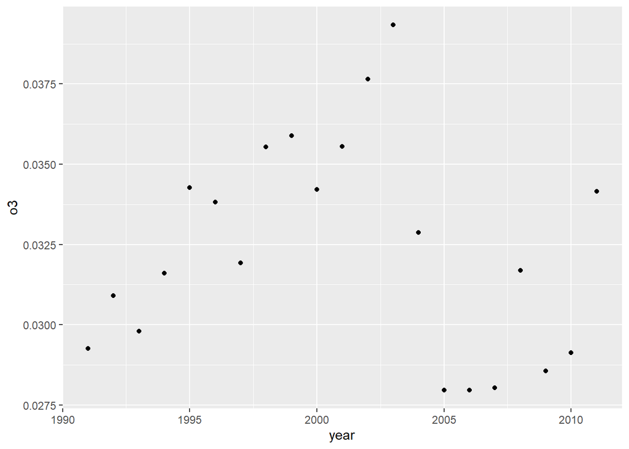

```r
loc_merced <- loc %>% filter(`County Abbr`== "MER")
q <- loc_merced$site
yearly_merced <- yearly %>% filter(site%in% q)
yearly_merced <-yearly_merced %>% filter(site=="3022")
ggplot(yearly_merced, aes(x=year, y=o3)) +
  geom_point()
```

and then gather all the data in the table

```r
knitr::kable(
  yearly_merced[,2:3 ], caption = 'The annual daily mean of o3 for Merced County.'
)
```

The annual daily mean of o3 for Merced County.

[output not shown]

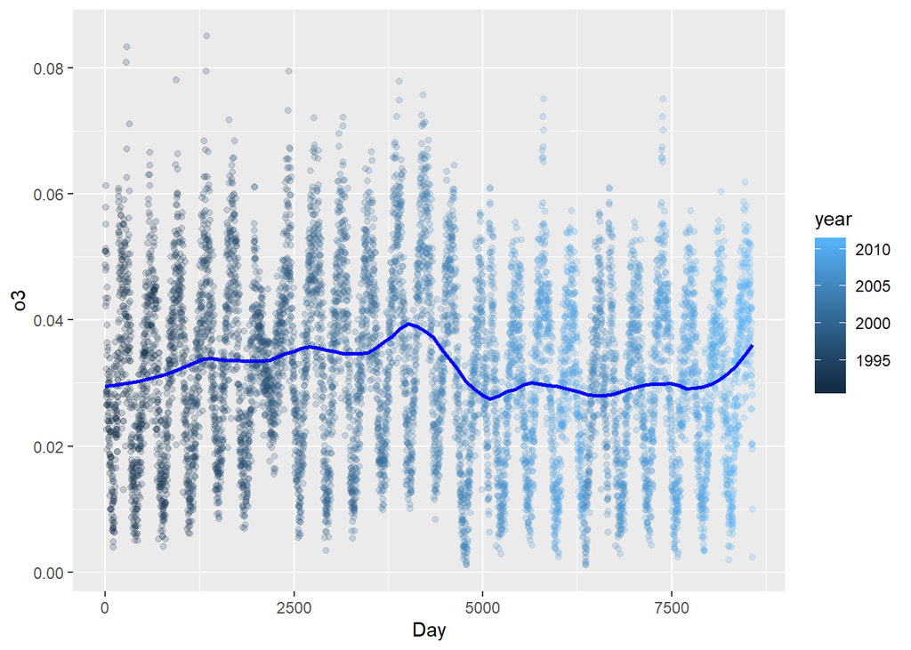

```r
#Specify it for Merced county
daily.site.merced <- daily.site%>% filter(site%in% "3022") # I chose one stataion in merced
#make a daily
daily.merced <- daily.site.merced  %>% select(site,o3,date,year) %>% na.omit()
daily.merced$time <- seq(1,length(daily.merced$date))
# i make time series of day
Day <- daily.merced $time # for the sake of cleanliness
o3 <- log(daily.merced $o3)
loess25 <- loess(Day~o3, degree = 2, span = 0.25) # 50% smoothing span
#plot time series quadratic
g <- ggplot(daily.merced , aes(x = Day, y = o3,color=year))+
  geom_point(alpha = 0.2, na.rm = T)
g <- g +
   geom_smooth(method = "loess", span = 0.25,method.args = list(degree=2), se = FALSE,color = "blue", na.rm = T)
g
```

Definitely, there is a seasonal trend

## Question 14

```r
#stl(loess25, s.degree = 0)
#error:  Error in complete.cases(object) : not all arguments have the same length
```